# The Return of the DAG

Fernando Miguez

11/4/2020

## From the Book of Why: Ladder of Causality

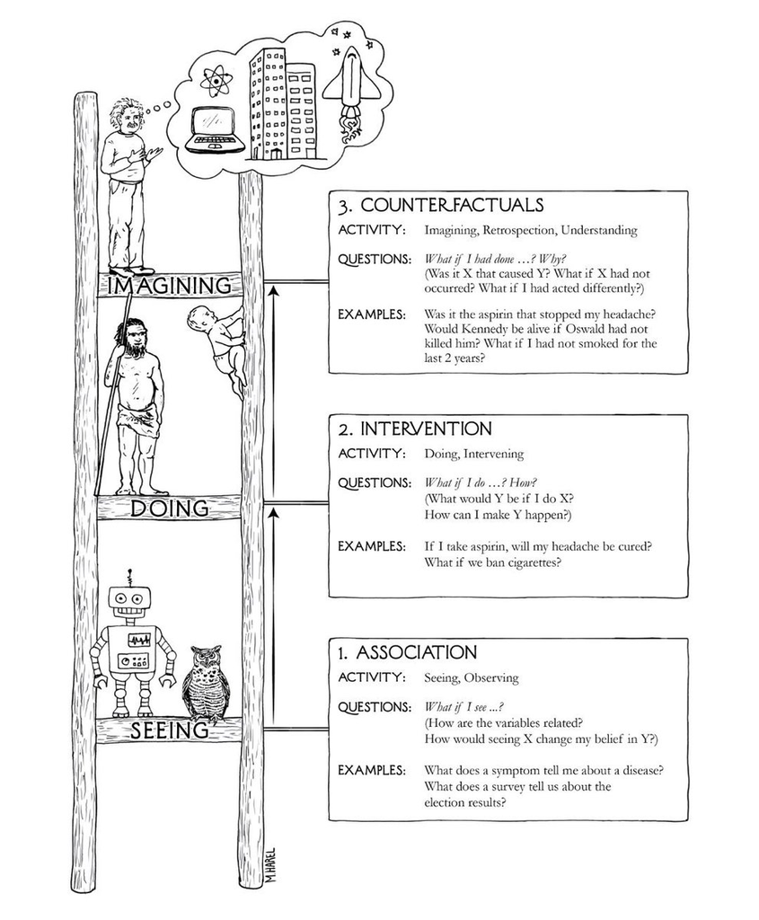

Ladder of Causality

## Soil Health and Yield

We might start with a vague hypothesis which states that soil health results in higher crop yields.

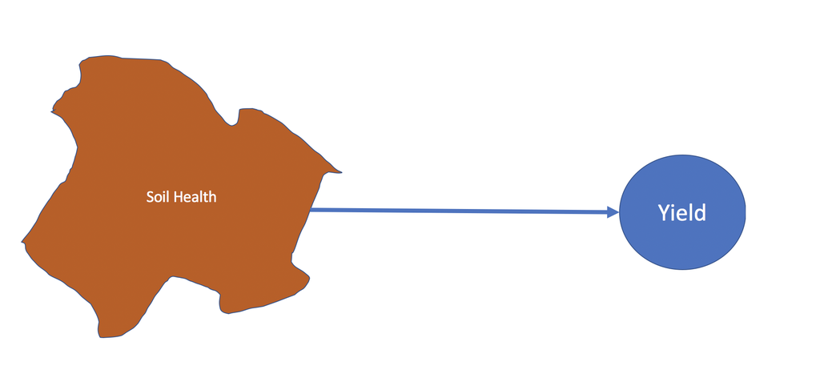

SoilHeatlhYields

Soil health, however, is a vague concept, so it could be replaced by soil organic matter (OM). Again, soil organic matter is not typically measured directly, but, indirectly through measuring soil organic carbon (SOC) - which itself is problematic, but this is another story.

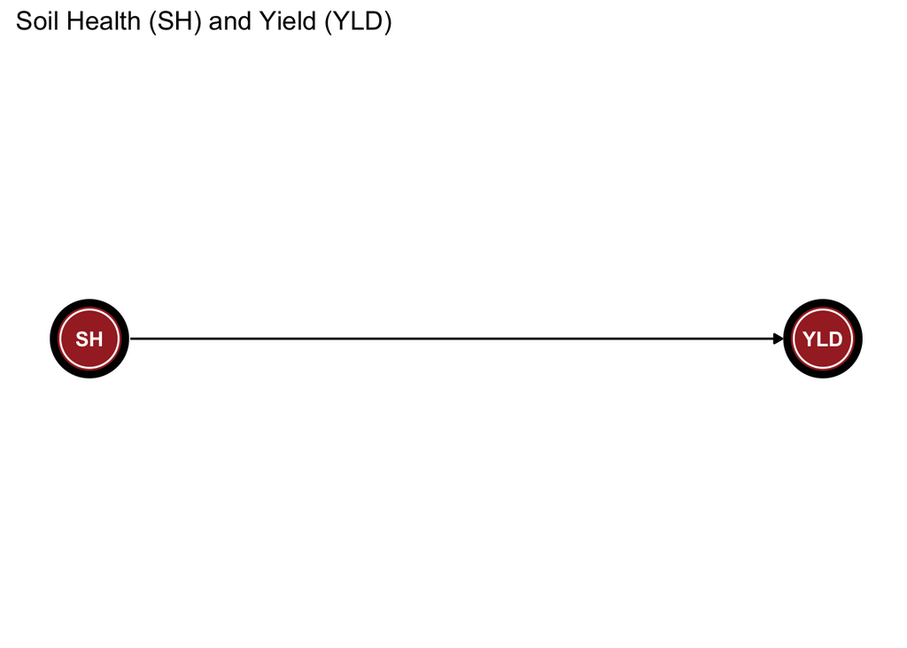

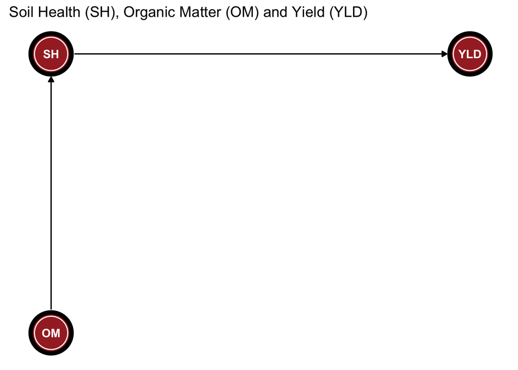

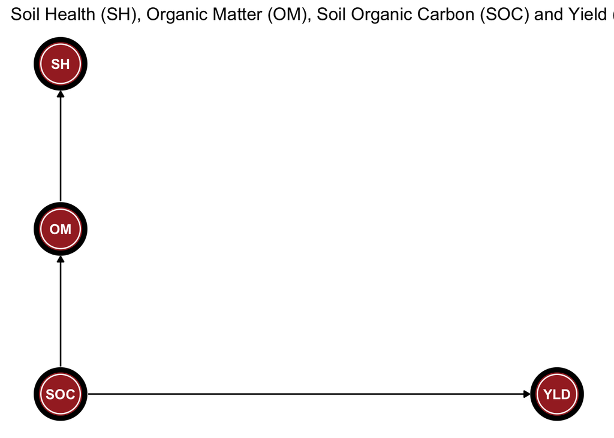

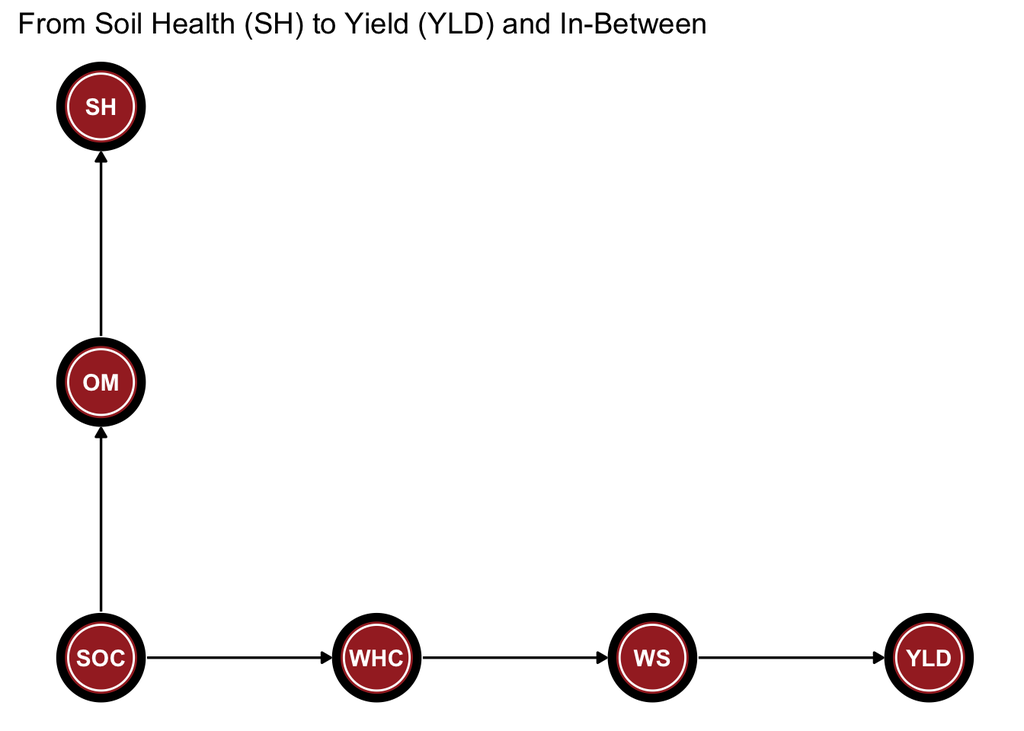

## Testing properties of the DAG

```r
impliedConditionalIndependencies(dag2)[[18]]
```

```
## SOC _||_ YLD | WS
```

```r
impliedConditionalIndependencies(dag2)[[19]]
```

```
## SOC _||_ YLD | WHC
```

## Making changes: Irrigation

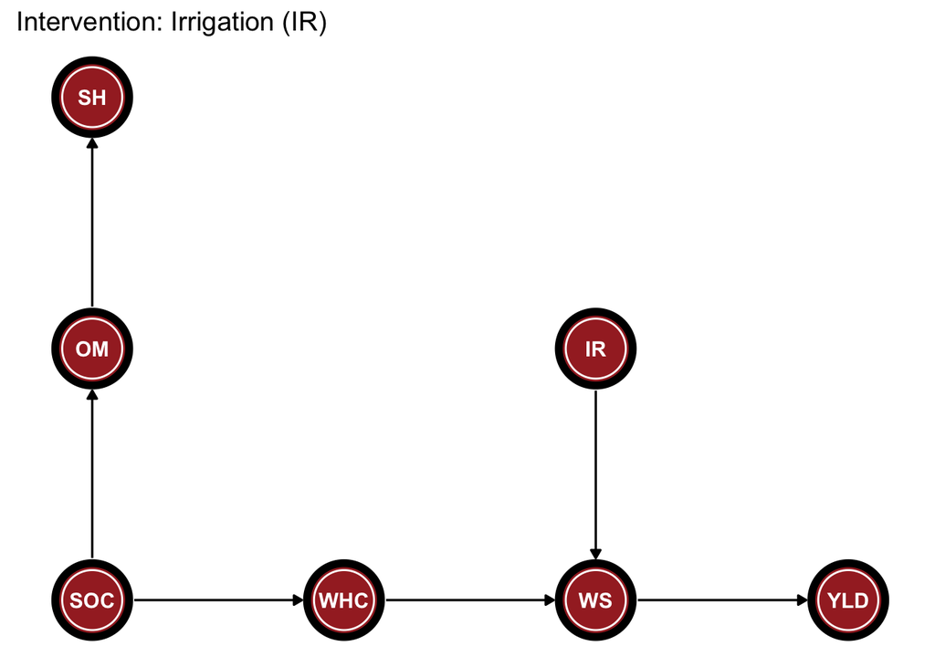

## Egli and Hatfield AJ 2014

Egli and Hatfield, 2014 (doi:10.2134/agronj2013.0364)

Below on the x-axis we have NCCPI (National Commodities Crop Productivity Index.)

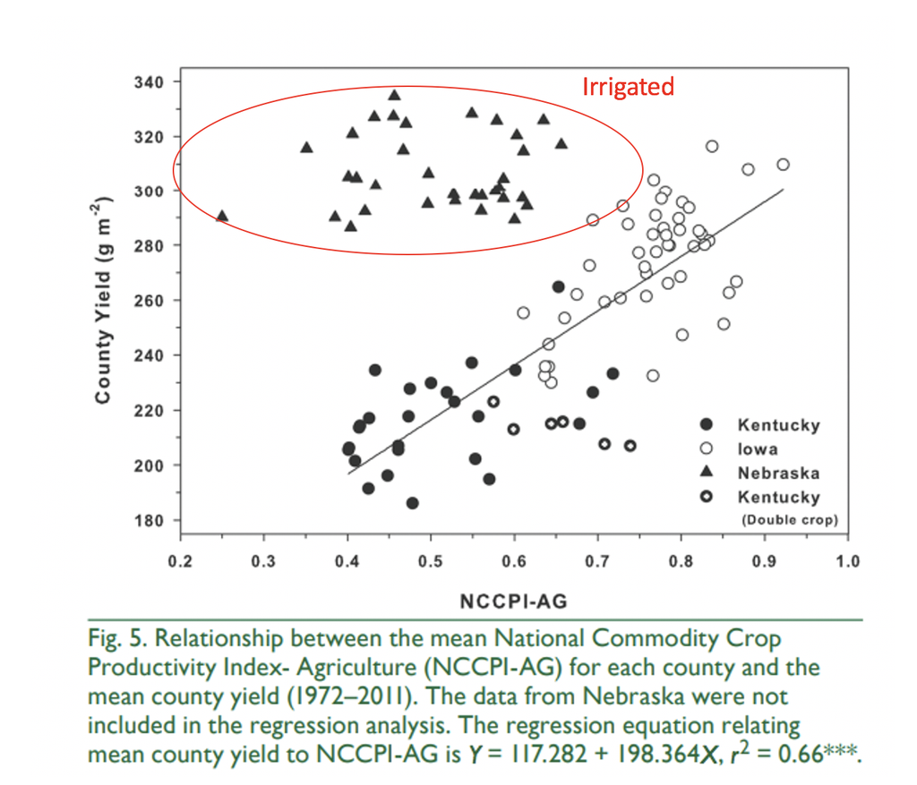

IrrigationEvidence

> The National Commodity Crop Productivity Index-Agriculture (NCCPI-AG) was developed to provide an indication of the ability of soils and climate to foster crop production (NRCS, 2008).

> The NCCPI, designed for non-irrigated production, was not related to yield in Nebraska because only irrigated production was included in the analysis.

> Relating the YGs to the ability of the soil to supply water to the crop suggests that the YGs in Iowa and Kentucky could be reduced significantly by increasing the soil water holding capacity (which may be difficult at best) or by irrigation (as apparently happened in Nebraska).

> It is difficult to evaluate the individual contributions of these three factors, but the association with NCCPI-AG suggests that other soil characteristics, in addition to the ability of the soils to supply water to the crop, may play a role in the variation of county yields in favorable environments

[figure not shown]

OM-WHC

## More to the DAG. Adding Crop Residue

From Wikipedia:

> In statistics, a confounder (also confounding variable, confounding factor, or lurking variable) is a variable that influences both the dependent variable and independent variable, causing a spurious association. Confounding is a causal concept, and as such, cannot be described in terms of correlations or associations

https://en.wikipedia.org/wiki/Confounding

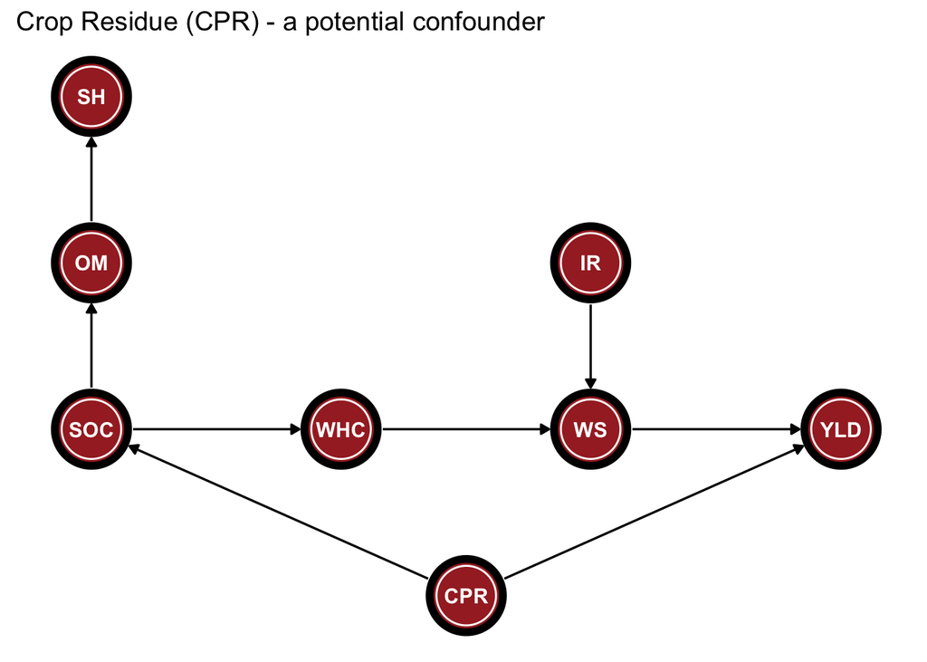

## Crop Residues do not directly affect yield

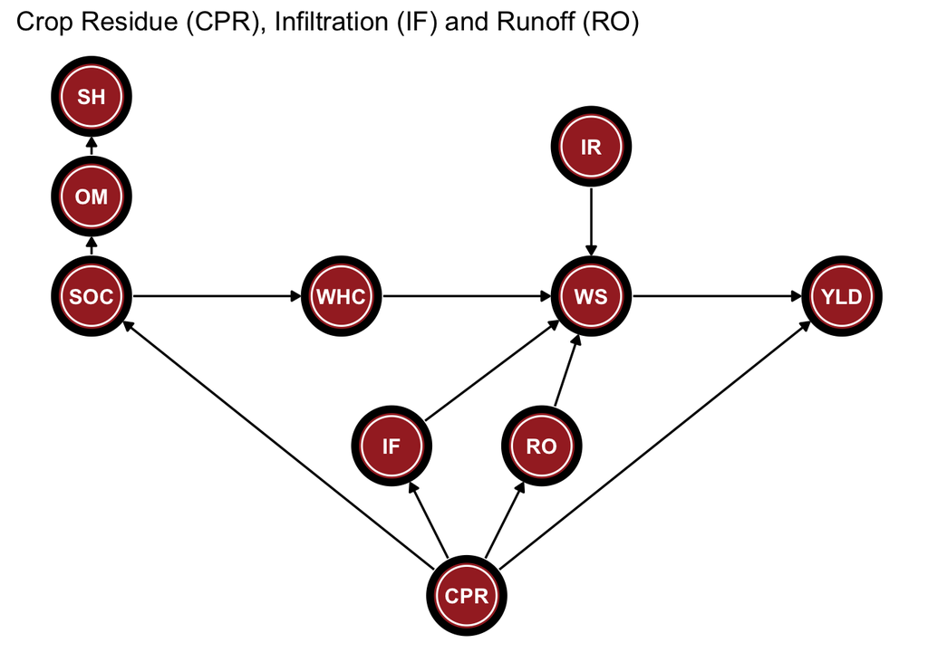

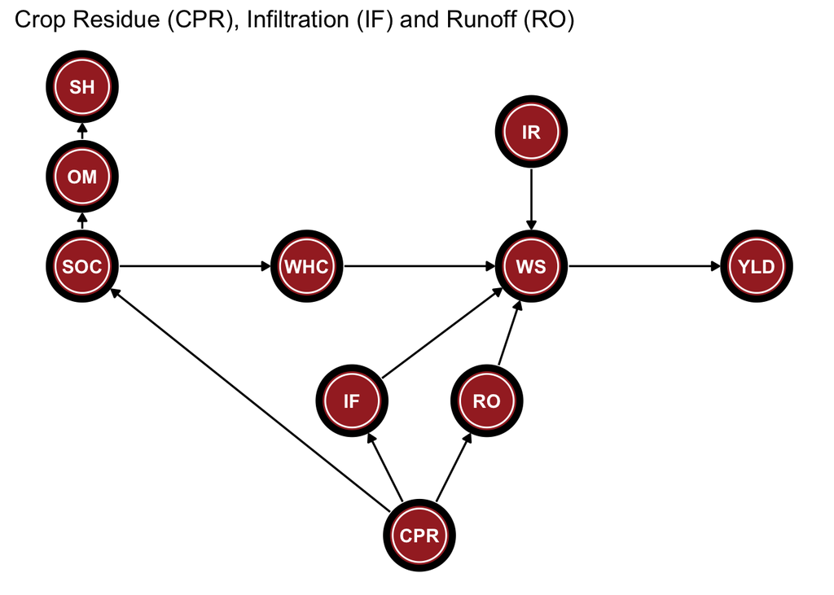

## Adjustment Sets

```r
adjustmentSets(dag5)
```

```
##  { CPR }
```

```r
adjustmentSets(dag6)
```

```
##  { IF, RO }
##  { CPR }
```

## Remarks

- This paper is NOT a deliberate intervention in which we explicitly test our hypothesis
- We would need to conduct experiments where we specifically manipulate the different variables
- SOC is difficult to manipulate! How do you change it while holding everything else constant!
- Practices such as rotations, cover crops, soil ammendments might increase SOC, but they also change other things.
- I think there is still a lot of confusion in agronomy about certain issues and this type of exercise in causal inference can be highly beneficial

## More on DAGs

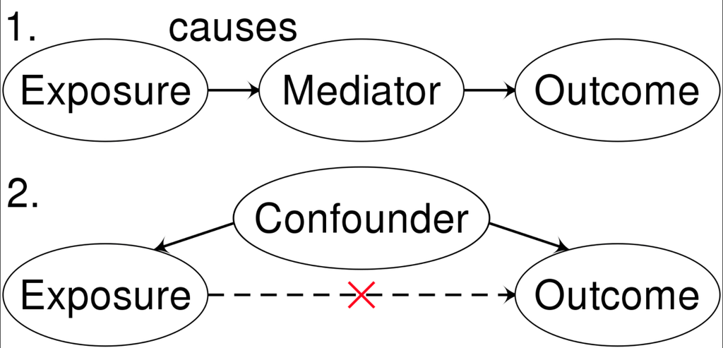

Mediator-Confounder

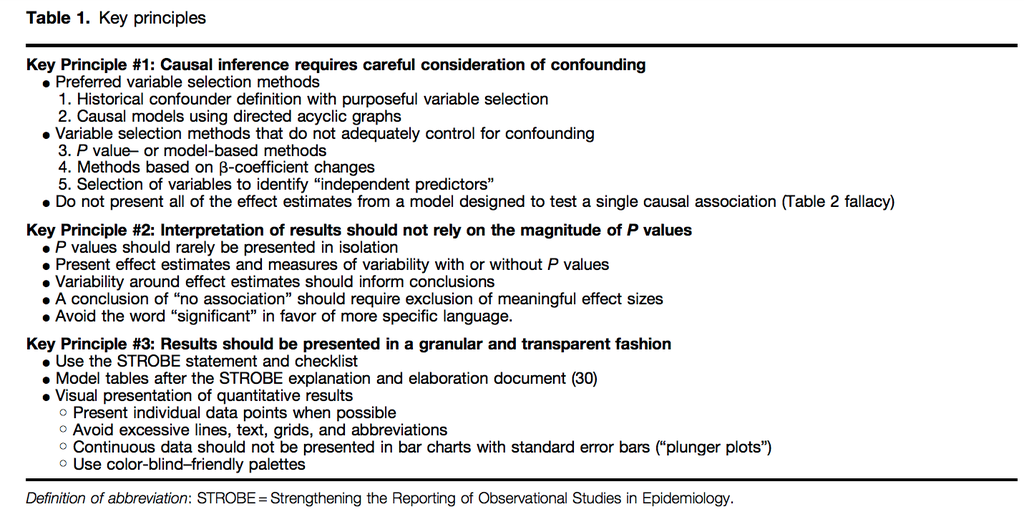

Key-Principles-Confounder